# Corporate Credit Card Transactions

# London Borough of Barnet

## Analysis of Credit Card Transactions, 2014-16 - 17?

### Prepared by Danilo Diaz , March 2024

### C0889539

### Installation of Libraries

```python
!pip install tabulate
!pip install -U scikit-learn
```

### Libraries

```python
import datetime
from tabulate import tabulate
import matplotlib.cm as cm
import matplotlib.pyplot as plt
import numpy as np
import pandas as pd
from scipy.stats import norm
from sklearn.cluster import KMeans
%matplotlib inline
#hide warnings
import warnings
warnings.filterwarnings('ignore')
```

- 1. Executive Summary
  - 1.1 Analysis Requests
- 2. The Data
- 3. Summary Graphs and Tables
- 4. Significant Changes in Spending Behavior
- 5. Classifying Creditors to Accounts
- 6. Grouping Service Areas
- 7. Anomaly Detection

## Executive Summary

### Analysis Requests

1. The Auditor would like to get a summary view of the transactions for each Service Area. The summary view would include at least one visual representation of the transactions in such a way that they could compare them by quarter. Quarters are defined based on the calendar year (Q1 is January to March, Q2 April to June, etc.). The Auditor would also like a summary table with some relevant statistics (The Auditor says something along the lines of “transaction counts and averages”, but welcomes ideas).
2. The Auditor would like to get a view if there are any significant changes in spending behavior by Service Area and by Account. Changes in behavior could be spikes, but could also be permanent increases in the transaction amounts. Please identify instances of both or show that they do not exist in the data.
3. The Auditor would like to get an understanding of how Creditors are classified into accounts. In particular, they are worried about transaction misclassification. Are you able to identify instances in which Creditors are not consistently classified into Accounts (e.g., most of the time Creditor “AirTickets.com” is classified into “Travelling Expenses”, but on some occasions it is also found in “Miscellaneous”)?
4. In terms of spending behavior (defined by the number and the typical size of transactions), are there Service Areas that behave similarly and can be grouped together? How?
5. The auditor has heard that you may know anomaly detection techniques. They would like to ask you for a sample of a few hundred transactions that are anomalous, different or worthwhile inquiring about. The sample should include at least five transactions for each Service Area. Please provide this sample and explain why they are special or different.

## 2. The Data

```python
df_2014 = pd.read_csv(filepath_or_buffer='data/Purchasing Card Data 2014 v1.csv', sep=',')
df_2015 = pd.read_csv(filepath_or_buffer='data/PCard Transactions 15-16.txt', sep=',')
df_2016 = pd.read_csv(filepath_or_buffer='data/PCard 1617.csv', sep=',')
df_2017 = pd.read_csv(filepath_or_buffer='data/1718Pcard.csv', sep=',')
```

#### First Rows of the Data 2014 - 2015 - 2016 - 2017

```python
display(df_2014.head(3))
```

|  | Service Area | Account Description | Creditor | Transaction Date | JV Reference | JV Date | JV Value |
| --- | --- | --- | --- | --- | --- | --- | --- |
| 0 | Childrens Services | IT Services | 123-REG.CO.UK | 23/04/2014 | 93 | 20/05/2014 | 143.81 |
| 1 | Childrens Services | Other Services | ACCESS EXPEDITIONS | 03/04/2014 | 111 | 20/05/2014 | 6,000.00 |
| 2 | Childrens Services | Equipment and Materials Repair | AFE SERVICELINE | 02/04/2014 | 6 | 20/05/2014 | 309.38 |

```python
display(df_2015.head(3))
```

|  | Service Area | Account Description | Creditor | Journal Date | Journal Reference | Total |
| --- | --- | --- | --- | --- | --- | --- |
| 0 | Assurance | Miscellaneous Expenses | 43033820 COSTA COFFEE | 18/08/2015 | 5,043.00 | 2 |
| 1 | Children's Family Services | Miscellaneous Expenses | 99 PLUS DISCOUNT MART | 08/06/2015 | 4,184.00 | 29.97 |
| 2 | Children's Family Services | E19 - Learning Resources | 99P STORES LTD | 07/12/2015 | 6,278.00 | 34.65 |

```python
display(df_2016.head(3))
```

|  | Service Area | Account Description | Creditor | Journal Date | Journal Reference | Total |
| --- | --- | --- | --- | --- | --- | --- |
| 0 | Adults and Communities | Books-CDs-Audio-Video | AMAZON EU | 05/12/2016 | 10,510.00 | 45.00 |
| 1 | Adults and Communities | Books-CDs-Audio-Video | AMAZON UK MARKETPLACE | 05/12/2016 | 10,509.00 | 426.57 |
| 2 | Adults and Communities | Books-CDs-Audio-Video | AMAZON UK RETAIL AMAZO | 06/12/2016 | 10,524.00 | 121.38 |

```python
display(df_2017.head(3))
```

|  | FIN.TRANSACTION DATE | FIN.POSTING DATE | FIN.TRANSACTION AMOUNT | MCH.MERCHANT NAME | MCH.CITY NAME | FIN.ORIGINAL CURRENCY AMOUNT | FIN.ORIGINAL ISO CURRENCY CODE SYMBOL | FIN.INET CONVERSION |
| --- | --- | --- | --- | --- | --- | --- | --- | --- |
| 0 | 06/04/17 | 07/04/17 | 36.55 | TESCO STORE 2296 | COLNEY HATCH | 36.55 | GBP | 1.00 |
| 1 | 06/04/17 | 07/04/17 | 58.75 | AMFBOWLING.CO.UK | 01442 840200 | 58.75 | GBP | 1.00 |
| 2 | 10/04/17 | 11/04/17 | 40.50 | WWW.GOJUMPIN.COM | INTERNET | 40.50 | GBP | 1.00 |

```python
#### Get Column Names of each dataframe

print(df_2014.columns)
print(df_2015.columns)
print(df_2016.columns)
print(df_2017.columns)
```

```
Index(['Service Area', 'Account Description', 'Creditor', 'Transaction Date',
       'JV Reference', 'JV Date', 'JV Value'],
      dtype='object')
Index(['Service Area', 'Account Description', 'Creditor', 'Journal Date',
       'Journal Reference', 'Total'],
      dtype='object')
Index(['Service Area', 'Account Description', 'Creditor', 'Journal Date',
       'Journal Reference', 'Total'],
      dtype='object')
Index(['FIN.TRANSACTION DATE', 'FIN.POSTING DATE', 'FIN.TRANSACTION AMOUNT',
       'MCH.MERCHANT NAME', 'MCH.CITY NAME', 'FIN.ORIGINAL CURRENCY AMOUNT',
       'FIN.ORIGINAL ISO CURRENCY CODE SYMBOL', 'FIN.INET CONVERSION'],
      dtype='object')
```

Base on the columns name we can inffer tha the data from 2017 is miising Service Area We can also see that the data from 2014,2015 and 2016 have the same columns names, so we can merge them.

```python
# correct the column names
culumns_names = ['Service Area',
                 'Account Description',
                 'Creditor',
                 'Journal Date',
                 'JV Reference',
                 'Total']
```

#### Columns Names 2014 - 2015 - 2016

```python
#### Rename Columns 2014
df_2014.drop('JV Date', axis = 1, inplace = True)
df_2014.columns = culumns_names

#### Rename Columns 2015
df_2015.columns = culumns_names

#### Rename Columns 2016
df_2016.columns = culumns_names
```

```python
df_2014.head(3)
```

|  | Service Area | Account Description | Creditor | Journal Date | JV Reference | Total |
| --- | --- | --- | --- | --- | --- | --- |
| 0 | Childrens Services | IT Services | 123-REG.CO.UK | 23/04/2014 | 93 | 143.81 |
| 1 | Childrens Services | Other Services | ACCESS EXPEDITIONS | 03/04/2014 | 111 | 6,000.00 |
| 2 | Childrens Services | Equipment and Materials Repair | AFE SERVICELINE | 02/04/2014 | 6 | 309.38 |

```python
df_2015.head(3)
```

|  | Service Area | Account Description | Creditor | Journal Date | JV Reference | Total |
| --- | --- | --- | --- | --- | --- | --- |
| 0 | Assurance | Miscellaneous Expenses | 43033820 COSTA COFFEE | 18/08/2015 | 5,043.00 | 2 |
| 1 | Children's Family Services | Miscellaneous Expenses | 99 PLUS DISCOUNT MART | 08/06/2015 | 4,184.00 | 29.97 |
| 2 | Children's Family Services | E19 - Learning Resources | 99P STORES LTD | 07/12/2015 | 6,278.00 | 34.65 |

```python
df_2016.head(3)
```

|  | Service Area | Account Description | Creditor | Journal Date | JV Reference | Total |
| --- | --- | --- | --- | --- | --- | --- |
| 0 | Adults and Communities | Books-CDs-Audio-Video | AMAZON EU | 05/12/2016 | 10,510.00 | 45.00 |
| 1 | Adults and Communities | Books-CDs-Audio-Video | AMAZON UK MARKETPLACE | 05/12/2016 | 10,509.00 | 426.57 |
| 2 | Adults and Communities | Books-CDs-Audio-Video | AMAZON UK RETAIL AMAZO | 06/12/2016 | 10,524.00 | 121.38 |

```python
# shape of the dataframes
print('2014:', df_2014.shape)
print('2015:', df_2015.shape)
print('2016:', df_2016.shape)
```

```
2014: (4142, 6)
2015: (3865, 6)
2016: (4582, 6)
```

##### Concatanating the data

```python
data = pd.concat((df_2014, df_2015, df_2016), axis = 0).reset_index(drop = True)
```

```python
# shape of the data
print('Data Shape:', data.shape)
```

```
Data Shape: (12589, 6)
```

#### Get some information about the data

```python
### check shape of the data
data.shape
```

```
(12589, 6)
```

```python
## Check duplicates

print('Duplicates:', data.duplicated().sum())
```

```
Duplicates: 0
```

```python
## Check missing values
print('Missing Values:', data.isnull().sum())

# Percentage of missing values

print('Percentage of Missing Values:', data.isnull().sum()/len(data)*100)
```

```
Missing Values: Service Area           1
Account Description    2
Creditor               2
Journal Date           2
JV Reference           2
Total                  0
dtype: int64
Percentage of Missing Values: Service Area          0.01
Account Description   0.02
Creditor              0.02
Journal Date          0.02
JV Reference          0.02
Total                 0.00
dtype: float64
```

```python
### check the data types
print('Data Types:', data.dtypes)
```

```
Data Types: Service Area            object
Account Description     object
Creditor                object
Journal Date            object
JV Reference           float64
Total                   object
dtype: object
```

```python
### Check the data
data.tail(3)
```

|  | Service Area | Account Description | Creditor | Journal Date | JV Reference | Total |
| --- | --- | --- | --- | --- | --- | --- |
| 12586 | Streetscene | Vehicle Running Costs | WWW.DVLA.GOV.UK | 25/08/2016 | 9,248.00 | 232.50 |
| 12587 | Streetscene | Vehicle Running Costs | WWW.MOT-TESTING-CP | 25/11/2016 | 10,384.00 | 68.00 |
| 12588 | Grand Total | NaN | NaN | NaN | NaN | 471,044.01 |

```python
### Get unique values from categorical columns and count them

for col in data.columns:
    if data[col].dtype == 'object':
        print(col, data[col].nunique())
```

```
Service Area 25
Account Description 67
Creditor 1936
Journal Date 739
Total 6292
```

#### Comments on Data

Based on the information, it is evident that the data comprises 6 columns and 12,589 rows. Additionally:

- There are some missing values; however, the percentage is low, so we can proceed to drop them.
- No duplicated values are present in the dataset.
- The data types of certain columns are incorrect, necessitating a change in their data types.

#### Data Wrangling

```python
# drop missing values
data.dropna(inplace = True)
# check the shape of the data
print('Data Shape:', data.shape)
#  journal date to datetime
data['Journal Date'] = pd.to_datetime(data['Journal Date'])

#total to float
data['Total'] = data['Total'].str.replace('$', '').str.replace(',', '').astype(float)

# check the data types
data.dtypes
```

```
Data Shape: (12587, 6)
```

```
Service Area                   object
Account Description            object
Creditor                       object
Journal Date           datetime64[ns]
JV Reference                  float64
Total                         float64
dtype: object
```

#### Columns Types

```python
# numerical columns
numerical_cols = data.select_dtypes(include = [np.number]).columns
# categorical columns
categorical_cols = data.select_dtypes(exclude = [np.number, np.datetime64]).columns
# time columns
time_cols = data.select_dtypes(include = [np.datetime64]).columns


print('Numerical Columns:', numerical_cols)

print('Categorical Columns:', categorical_cols)
```

```
Numerical Columns: Index(['JV Reference', 'Total'], dtype='object')
Categorical Columns: Index(['Service Area', 'Account Description', 'Creditor'], dtype='object')
```

#### Numerical Columns Analysis

```python
### Get the summary statistics of the numerical columns
data[numerical_cols].describe()
```

|  | JV Reference | Total |
| --- | --- | --- |
| count | 12,587.00 | 12,587.00 |
| mean | 6,126.85 | 99.82 |
| std | 3,248.97 | 391.39 |
| min | 1.00 | -4,707.00 |
| 25% | 3,943.50 | 10.00 |
| 50% | 5,795.00 | 26.83 |
| 75% | 8,847.50 | 92.05 |
| max | 12,136.00 | 15,340.80 |

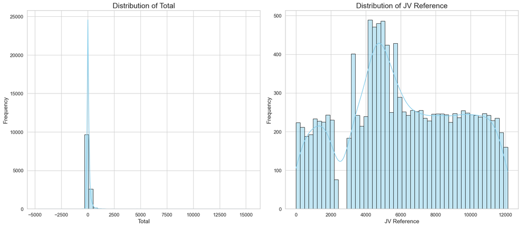

```python
import seaborn as sns
import matplotlib.pyplot as plt

# Set style for better aesthetics

# Create subplots
fig, axes = plt.subplots(nrows=1, ncols=2, figsize=(18, 8))

# Plot distribution of 'Total' column
sns.histplot(data['Total'], bins=50, kde=True, color='skyblue', edgecolor='black', ax=axes[0])
axes[0].set_title('Distribution of Total', fontsize=18)
axes[0].set_xlabel('Total', fontsize=14)
axes[0].set_ylabel('Frequency', fontsize=14)
axes[0].tick_params(axis='both', labelsize=12)

# Plot distribution of 'JV Reference' column
sns.histplot(data['JV Reference'], bins=50, kde=True, color='skyblue', edgecolor='black', ax=axes[1])
axes[1].set_title('Distribution of JV Reference', fontsize=18)
axes[1].set_xlabel('JV Reference', fontsize=14)
axes[1].set_ylabel('Frequency', fontsize=14)
axes[1].tick_params(axis='both', labelsize=12)

# Adjust layout
plt.tight_layout()
plt.show()
```

```python
### Get maximum value of total and its index

max_total = data['Total'].max()
max_total_index = data['Total'].idxmax()

print('Max Total:', max_total)

print('Max Total Index:', max_total_index)

### Get the row with the maximum total
data.loc[max_total_index]
```

```
Max Total: 15340.8
Max Total Index: 5730
```

```
Service Area           Customer Support Group
Account Description          Fees and Charges
Creditor                   HMCOURTS-SERVICE.G
Journal Date              2015-05-20 00:00:00
JV Reference                         3,161.00
Total                               15,340.80
Name: 5730, dtype: object
```

```python
# get the top 10 highest total

top_10_total = data.nlargest(10, 'Total')

print('Top 10 Total:', top_10_total)
```

```
Top 10 Total:                  Service Area   Account Description            Creditor  \
5730   Customer Support Group      Fees and Charges  HMCOURTS-SERVICE.G
12350  Customer Support Group  Legal and Court Fees  HMCOURTS-SERVICE.G
12353  Customer Support Group  Legal and Court Fees  HMCOURTS-SERVICE.G
1856       CSG Managed Budget  Legal and Court Fees  HMCOURTS-SERVICE.G
12359  Customer Support Group  Legal and Court Fees  HMCOURTS-SERVICE.G
531        CSG Managed Budget  Legal and Court Fees  HMCOURTS-SERVICE.G
5731   Customer Support Group      Fees and Charges  HMCOURTS-SERVICE.G
532        CSG Managed Budget  Legal and Court Fees  HMCOURTS-SERVICE.G
12351  Customer Support Group  Legal and Court Fees  HMCOURTS-SERVICE.G
77                 Governance        Other Services  BETTER LIFE HEALTH

      Journal Date  JV Reference     Total
5730    2015-05-20      3,161.00 15,340.80
12350   2016-06-23      8,504.00 11,487.00
12353   2016-05-26      8,190.00 11,088.00
1856    2014-09-23      2,235.00  8,058.00
12359   2017-01-30     10,995.00  7,968.00
531     2014-05-22        498.00  7,800.00
5731    2015-07-21      4,722.00  6,955.20
532     2014-05-22        497.00  6,777.00
12351   2016-11-23     10,357.00  6,762.00
77      2014-04-24        286.00  6,388.20
```

- Both columns have a similar count, indicating that there are no missing values.
- 'JV Reference' has a higher mean and standard deviation compared to 'Total.'
- 'Total' has a wider range, especially with a negative minimum value, suggesting potential outliers or errors in the data.

#### Categorical Columns Analysis

```python
data.head(3)
```

|  | Service Area | Account Description | Creditor | Journal Date | JV Reference | Total |
| --- | --- | --- | --- | --- | --- | --- |
| 0 | Childrens Services | IT Services | 123-REG.CO.UK | 2014-04-23 | 93.00 | 143.81 |
| 1 | Childrens Services | Other Services | ACCESS EXPEDITIONS | 2014-04-03 | 111.00 | 6,000.00 |
| 2 | Childrens Services | Equipment and Materials Repair | AFE SERVICELINE | 2014-04-02 | 6.00 | 309.38 |

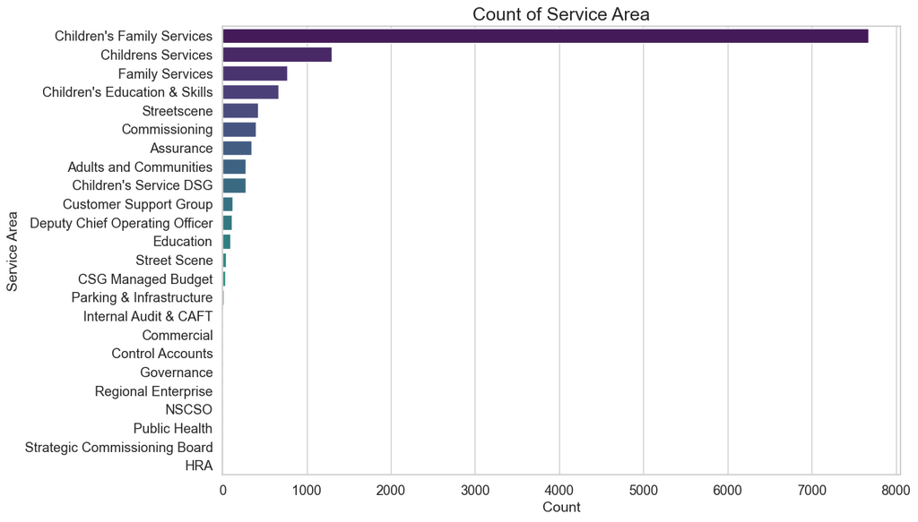

```
Number of Service Areas: 24
```

```python
# Plot All service areas
plt.figure(figsize=(12, 8))
sns.countplot(y='Service Area', data=data, palette='viridis', order=data['Service Area'].value_counts().index)
plt.title('Count of Service Area', fontsize=18)
plt.xlabel('Count', fontsize=14)
plt.ylabel('Service Area', fontsize=14)
plt.show()

## Nunbers of service areas

print('Number of Service Areas:', data['Service Area'].nunique())
```

```python
### Get the top 10 service areas

top_10_service_area = data['Service Area'].value_counts().nlargest(10)

print('Top 10 Service Area:', top_10_service_area)
```

```
Top 10 Service Area: Service Area
Children's Family Services       7672
Childrens Services               1297
Family Services                   770
Children's Education & Skills     667
Streetscene                       420
Commissioning                     400
Assurance                         344
Adults and Communities            278
Children's Service DSG            277
Customer Support Group            117
Name: count, dtype: int64
```

```
Number of Account Description: 67
Top 10 Account Description: Account Description
Equipment and Materials Purcha    2676
Food Costs                        2245
Travelling Expenses               1084
Other Services                     971
Other Transfer Payments to Soc     865
Cleaning and domestic material     688
Miscellaneous Expenses             603
Building Repairs & Maintenance     431
Books-CDs-Audio-Video              425
Stationery                         312
Name: count, dtype: int64
```

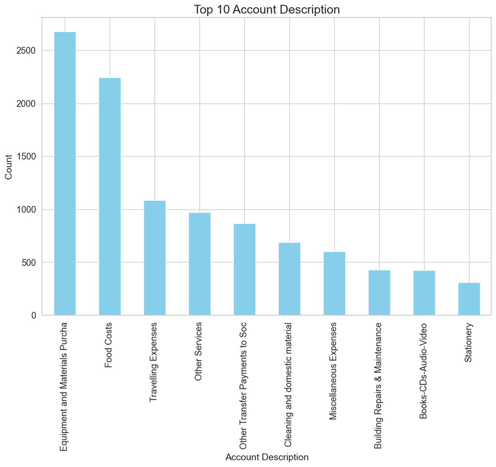

```python
# Plot all accounts and count

print('Number of Account Description:', data['Account Description'].nunique())
top_10_account_description = data['Account Description'].value_counts().nlargest(10)
print('Top 10 Account Description:', top_10_account_description)


# Plot just top 10 accounts

top_10_account_description.plot(kind='bar', figsize=(12, 8), color='skyblue')
plt.title('Top 10 Account Description', fontsize=18)
plt.xlabel('Account Description', fontsize=14)
plt.ylabel('Count', fontsize=14)
plt.show()
```

```python
creditors = np.unique(data['Creditor'])
num_creditors = len(creditors)
print('Number of Creditors:', num_creditors)
```

```
Number of Creditors: 1936
```

```python
earliest_date = data['Journal Date'].min()
latest_date = data['Journal Date'].max()

# Create a list of tuples for tabulating
table_data = [
    ('Earliest Date', earliest_date),
    ('Latest Date', latest_date)
]

table = tabulate(table_data, headers=['Date Type', 'Date'], tablefmt='fancy_grid')
print(table)
```

```
╒═══════════════╤═════════════════════╕
│ Date Type     │ Date                │
╞═══════════════╪═════════════════════╡
│ Earliest Date │ 2014-04-02 00:00:00 │
├───────────────┼─────────────────────┤
│ Latest Date   │ 2017-04-03 00:00:00 │
╘═══════════════╧═════════════════════╛
```

#### Quarter Column

```python
# convert date strings to datetime and create quarters column
data['Quarter'] = data['Journal Date'].dt.to_period('Q')


num_transactions_per_quarter = data['Quarter'].value_counts().sort_index(ascending=True)

#Print unique quarters

print('Number Quarters:', len(data['Quarter'].unique()))
```

```
Number Quarters: 13
```

## 2. Summary Graphs and Tables

Create a class to make the analysis easier, based on the requests of the Auditor. taking account quarter, service area, account and creditor.

```python
import numpy as np
import pandas as pd
import matplotlib.pyplot as plt

class QuarterAggPlotter:
    def __init__(self, data):
        self.data = data
        self.quarters = data['Quarter'].unique()
        self.num_quarters = len(data['Quarter'].unique())
        self.service_areas = data['Service Area'].unique()
        self.num_service_areas = len(data['Service Area'].unique())

    def plot_single_subplot(self, ax, heights, color, agg_name, title):
        """
        Plots a single subplot with bar chart.

        Parameters:
        - ax: matplotlib axes object
        - heights: list or array of bar heights
        - color: color of the bars
        - agg_name: label for the y-axis
        - title: title of the subplot
        """
        ind = np.arange(self.num_quarters)
        width = 0.35

        bars = ax.bar(ind, heights, width, color=color)

        ax.set_xticks(ind + (width / 2))
        ax.set_xticklabels(self.quarters)

        ax.set_xlim(-0.5, self.num_quarters)

        ax.set_xlabel("Quarter")
        ax.set_ylabel(agg_name)
        ax.set_title(title, y=1.05, fontsize=14)


        for bar in bars:
            height = bar.get_height()
            ax.annotate(f'{height:.2f}',
                        xy=(bar.get_x() + bar.get_width() / 2, height),
                        xytext=(0, 3),
                        textcoords="offset points",
                        ha='center', va='bottom', fontsize=10, color='black')

    def plot_transactions_overall(self, table, agg_name, color = 'green'):

        # allocate subplots
        fig = plt.figure(figsize = (12, 2))
        ax = fig.add_subplot(1, 1, 1)

        self.plot_single_subplot(ax, table[0], color, agg_name, "All Service Areas".upper())

        # show plot
        plt.show()

    def create_qtr_agg_table_overall(self, agg_func):
        """
        Creates a pivot table for a given aggregate function.

        Parameters:
        - agg_func: function to aggregate data

        Returns:
        - pandas DataFrame with aggregated values for each quarter
        """

        aggs = np.zeros(self.num_quarters)
        for qtr in range(self.num_quarters):
            aggs[qtr] = agg_func(data[data['Quarter'] == self.quarters[qtr]]['Total'])
        aggs[np.isnan(aggs) == True] = 0.0
        aggs_df = pd.DataFrame(aggs.reshape(-1, 1))
        aggs_df.index = self.quarters

        return aggs_df

    def create_qtr_agg_table(self, agg_func):
        aggs = np.zeros((self.num_service_areas, self.num_quarters))
        for area in range(self.num_service_areas):
            for qtr in range(self.num_quarters):
                aggs[area, qtr] = agg_func(data[(data['Service Area'] == self.service_areas[area]) & \
                                        (data['Quarter'] == self.quarters[qtr])]['Total'])
        aggs[np.isnan(aggs) == True] = 0.0
        aggs_df = pd.DataFrame(aggs)
        aggs_df.columns = self.quarters
        aggs_df.index = self.service_areas

        return aggs_df

    def plot_aggregated_data(self, agg_func, color, agg_name, title):


        # Create a figure and axis
        fig, ax = plt.subplots(1, 1, figsize=(12, 6))

        # Create aggregated table
        aggs_df = self.create_qtr_agg_table_overall(agg_func)

        # Plot single subplot
        self.plot_single_subplot(ax, aggs_df[0], color, agg_name, title)
        # Show the plot
        plt.show()

    def plot_tables(self, table, agg_name, color = 'darkblue'):

        # allocate subplots
        fig, ax_ar = plt.subplots(self.num_service_areas, 1, figsize = (12, 55))

        # create all subplots
        for index in range(self.num_service_areas):
            self.plot_single_subplot(ax_ar[index], table.iloc[index, :], color, agg_name, self.service_areas[index])

        # show plot
        plt.tight_layout()
        plt.show()

    def summary_table(self):
        """
        Creates a summary table for the data.

        Returns:
        - pandas DataFrame with aggregated values for each quarter
        """

        # Create aggregated table
        pd.options.display.float_format = '{:,.0f}'.format
        pd.set_option('display.max_rows', self.num_service_areas * self.num_quarters)

        data_qtr = self.data.groupby(['Service Area', 'Quarter'])
        summary = data_qtr[['Total']].agg((np.count_nonzero, np.sum, np.mean))

        summary.columns = summary.columns.set_levels(['Transactions'], level = 0)
        summary.columns = summary.columns.set_levels(['Count', 'Sum ($)', 'Average ($)'], level = 1)

        return summary
```

#### Intance of the class

```python
# Create an instance of the QuarterAggPlotter class
quarter_agg_plotter = QuarterAggPlotter(data)
```

We offer comprehensive support for our graphical data through the inclusion of four summary tables. The primary table employs a hierarchical structure to present a detailed breakdown of quarterly spending across service areas, exclusively featuring active quarters. This table encompasses counts, sums, and averages for a holistic perspective. Additionally, the subsequent trio of tables provides a granular breakdown of the three aggregates, organized by both service area and quarter. While the hierarchical table facilitates a focused examination of specific service areas, the grid tables prove invaluable for scrutinizing trends over time.

### Transactions Counts by Quarter

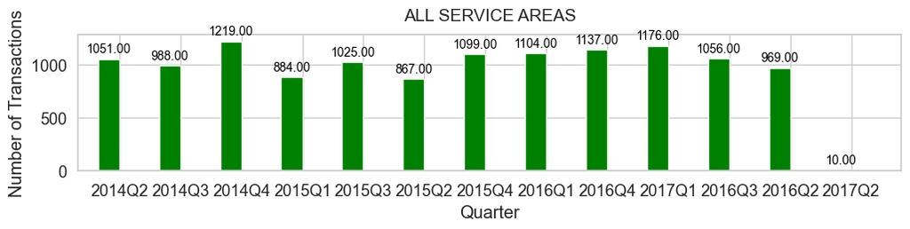

```python
### Transaction Counts by Quarter
services_areas_counts_qtr_overall = quarter_agg_plotter.create_qtr_agg_table_overall(np.count_nonzero)
quarter_agg_plotter.plot_transactions_overall(services_areas_counts_qtr_overall, 'Number of Transactions', 'green')
```

```python
services_areas_counts_qtr = quarter_agg_plotter.create_qtr_agg_table(np.count_nonzero)
```

```python
display(services_areas_counts_qtr)
```

|  | 2014Q2 | 2014Q3 | 2014Q4 | 2015Q1 | 2015Q3 | 2015Q2 | 2015Q4 | 2016Q1 | 2016Q4 | 2017Q1 | 2016Q3 | 2016Q2 | 2017Q2 |
| --- | --- | --- | --- | --- | --- | --- | --- | --- | --- | --- | --- | --- | --- |
| Childrens Services | 946.00 | 331.00 | 20.00 | 0.00 | 0.00 | 0.00 | 0.00 | 0.00 | 0.00 | 0.00 | 0.00 | 0.00 | 0.00 |
| Control Accounts | 8.00 | 0.00 | 0.00 | 0.00 | 0.00 | 0.00 | 0.00 | 0.00 | 0.00 | 0.00 | 0.00 | 0.00 | 0.00 |
| Street Scene | 11.00 | 16.00 | 12.00 | 0.00 | 0.00 | 0.00 | 0.00 | 0.00 | 0.00 | 0.00 | 0.00 | 0.00 | 0.00 |
| Governance | 4.00 | 3.00 | 1.00 | 0.00 | 0.00 | 0.00 | 0.00 | 0.00 | 0.00 | 0.00 | 0.00 | 0.00 | 0.00 |
| Deputy Chief Operating Officer | 40.00 | 49.00 | 24.00 | 0.00 | 0.00 | 0.00 | 0.00 | 0.00 | 0.00 | 0.00 | 0.00 | 0.00 | 0.00 |
| Public Health | 2.00 | 0.00 | 0.00 | 0.00 | 0.00 | 0.00 | 0.00 | 0.00 | 0.00 | 0.00 | 0.00 | 1.00 | 0.00 |
| Adults and Communities | 16.00 | 8.00 | 18.00 | 11.00 | 15.00 | 8.00 | 19.00 | 23.00 | 45.00 | 52.00 | 37.00 | 25.00 | 1.00 |
| Internal Audit & CAFT | 2.00 | 7.00 | 2.00 | 0.00 | 0.00 | 0.00 | 0.00 | 0.00 | 0.00 | 0.00 | 0.00 | 0.00 | 0.00 |
| NSCSO | 1.00 | 2.00 | 0.00 | 0.00 | 0.00 | 0.00 | 0.00 | 0.00 | 0.00 | 0.00 | 0.00 | 0.00 | 0.00 |
| CSG Managed Budget | 20.00 | 12.00 | 4.00 | 0.00 | 0.00 | 0.00 | 0.00 | 0.00 | 0.00 | 0.00 | 0.00 | 0.00 | 0.00 |
| Strategic Commissioning Board | 1.00 | 0.00 | 0.00 | 0.00 | 0.00 | 0.00 | 0.00 | 0.00 | 0.00 | 0.00 | 0.00 | 0.00 | 0.00 |
| Family Services | 0.00 | 460.00 | 310.00 | 0.00 | 0.00 | 0.00 | 0.00 | 0.00 | 0.00 | 0.00 | 0.00 | 0.00 | 0.00 |
| Children's Service DSG | 0.00 | 31.00 | 32.00 | 15.00 | 20.00 | 12.00 | 59.00 | 31.00 | 24.00 | 10.00 | 19.00 | 24.00 | 0.00 |
| Education | 0.00 | 60.00 | 35.00 | 0.00 | 0.00 | 0.00 | 0.00 | 0.00 | 0.00 | 0.00 | 0.00 | 0.00 | 0.00 |
| Commercial | 0.00 | 9.00 | 0.00 | 0.00 | 0.00 | 0.00 | 0.00 | 0.00 | 0.00 | 0.00 | 0.00 | 0.00 | 0.00 |
| Children's Family Services | 0.00 | 0.00 | 597.00 | 607.00 | 750.00 | 590.00 | 814.00 | 867.00 | 895.00 | 980.00 | 804.00 | 758.00 | 8.00 |
| Commissioning | 0.00 | 0.00 | 44.00 | 29.00 | 18.00 | 11.00 | 40.00 | 62.00 | 52.00 | 38.00 | 63.00 | 43.00 | 0.00 |
| Streetscene | 0.00 | 0.00 | 25.00 | 37.00 | 72.00 | 23.00 | 36.00 | 27.00 | 48.00 | 41.00 | 73.00 | 37.00 | 1.00 |
| Parking & Infrastructure | 0.00 | 0.00 | 2.00 | 1.00 | 0.00 | 0.00 | 1.00 | 0.00 | 2.00 | 4.00 | 1.00 | 1.00 | 0.00 |
| Children's Education & Skills | 0.00 | 0.00 | 72.00 | 165.00 | 96.00 | 160.00 | 86.00 | 55.00 | 6.00 | 2.00 | 15.00 | 10.00 | 0.00 |
| Customer Support Group | 0.00 | 0.00 | 18.00 | 14.00 | 15.00 | 11.00 | 13.00 | 9.00 | 10.00 | 10.00 | 7.00 | 10.00 | 0.00 |
| Assurance | 0.00 | 0.00 | 3.00 | 4.00 | 39.00 | 52.00 | 30.00 | 29.00 | 53.00 | 38.00 | 36.00 | 60.00 | 0.00 |
| Regional Enterprise | 0.00 | 0.00 | 0.00 | 1.00 | 0.00 | 0.00 | 1.00 | 1.00 | 1.00 | 1.00 | 1.00 | 0.00 | 0.00 |
| HRA | 0.00 | 0.00 | 0.00 | 0.00 | 0.00 | 0.00 | 0.00 | 0.00 | 1.00 | 0.00 | 0.00 | 0.00 | 0.00 |

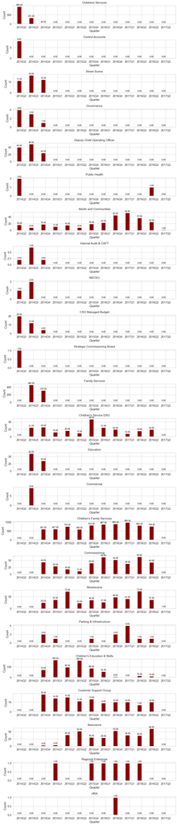

```python
quarter_agg_plotter.plot_tables(services_areas_counts_qtr, 'Count', 'darkred')
```

### Transaction Sums by Quarter

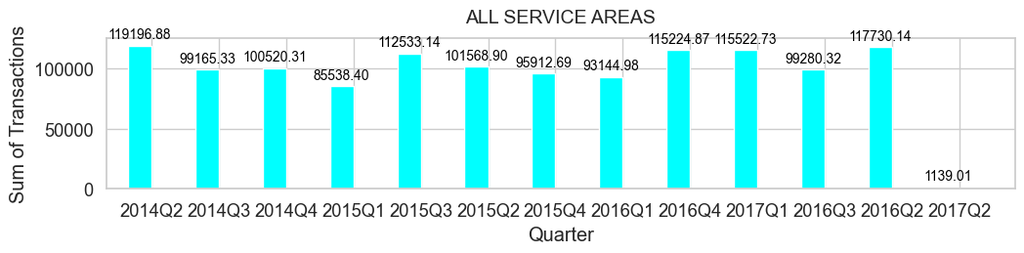

```python
### Transaction Sum by Quarter
services_areas_sum_qtr_overall = quarter_agg_plotter.create_qtr_agg_table_overall(np.sum)
quarter_agg_plotter.plot_transactions_overall(services_areas_sum_qtr_overall, 'Sum of Transactions', 'cyan')
```

```python
services_areas_sum_qtr = quarter_agg_plotter.create_qtr_agg_table(np.sum)
```

```python
display(services_areas_sum_qtr)
```

|  | 2014Q2 | 2014Q3 | 2014Q4 | 2015Q1 | 2015Q3 | 2015Q2 | 2015Q4 | 2016Q1 | 2016Q4 | 2017Q1 | 2016Q3 | 2016Q2 | 2017Q2 |
| --- | --- | --- | --- | --- | --- | --- | --- | --- | --- | --- | --- | --- | --- |
| Childrens Services | 66,339.06 | 23,999.07 | 1,264.11 | 0.00 | 0.00 | 0.00 | 0.00 | 0.00 | 0.00 | 0.00 | 0.00 | 0.00 | 0.00 |
| Control Accounts | 190.71 | 0.00 | 0.00 | 0.00 | 0.00 | 0.00 | 0.00 | 0.00 | 0.00 | 0.00 | 0.00 | 0.00 | 0.00 |
| Street Scene | 630.08 | 570.63 | 1,331.55 | 0.00 | 0.00 | 0.00 | 0.00 | 0.00 | 0.00 | 0.00 | 0.00 | 0.00 | 0.00 |
| Governance | 13,011.60 | 1,176.96 | 53.94 | 0.00 | 0.00 | 0.00 | 0.00 | 0.00 | 0.00 | 0.00 | 0.00 | 0.00 | 0.00 |
| Deputy Chief Operating Officer | 1,591.24 | 1,728.23 | 848.91 | 0.00 | 0.00 | 0.00 | 0.00 | 0.00 | 0.00 | 0.00 | 0.00 | 0.00 | 0.00 |
| Public Health | -2.35 | 0.00 | 0.00 | 0.00 | 0.00 | 0.00 | 0.00 | 0.00 | 0.00 | 0.00 | 0.00 | 4.55 | 0.00 |
| Adults and Communities | 4,608.00 | 2,570.45 | 2,149.33 | 2,017.86 | 1,635.85 | 1,187.40 | 3,039.03 | 2,468.52 | 9,117.74 | 9,165.53 | 6,742.40 | 3,659.22 | 79.00 |
| Internal Audit & CAFT | 407.20 | 192.95 | 116.00 | 0.00 | 0.00 | 0.00 | 0.00 | 0.00 | 0.00 | 0.00 | 0.00 | 0.00 | 0.00 |
| NSCSO | 10.00 | 445.50 | 0.00 | 0.00 | 0.00 | 0.00 | 0.00 | 0.00 | 0.00 | 0.00 | 0.00 | 0.00 | 0.00 |
| CSG Managed Budget | 32,167.34 | 24,549.00 | 14,270.00 | 0.00 | 0.00 | 0.00 | 0.00 | 0.00 | 0.00 | 0.00 | 0.00 | 0.00 | 0.00 |
| Strategic Commissioning Board | 244.00 | 0.00 | 0.00 | 0.00 | 0.00 | 0.00 | 0.00 | 0.00 | 0.00 | 0.00 | 0.00 | 0.00 | 0.00 |
| Family Services | 0.00 | 30,283.29 | 17,694.70 | 0.00 | 0.00 | 0.00 | 0.00 | 0.00 | 0.00 | 0.00 | 0.00 | 0.00 | 0.00 |
| Children's Service DSG | 0.00 | 3,047.75 | 5,213.69 | 3,030.71 | 2,776.49 | 1,543.27 | 4,530.62 | 4,457.30 | 1,599.30 | 168.33 | 2,618.12 | 3,342.69 | 0.00 |
| Education | 0.00 | 7,858.45 | 4,956.69 | 0.00 | 0.00 | 0.00 | 0.00 | 0.00 | 0.00 | 0.00 | 0.00 | 0.00 | 0.00 |
| Commercial | 0.00 | 2,743.05 | 0.00 | 0.00 | 0.00 | 0.00 | 0.00 | 0.00 | 0.00 | 0.00 | 0.00 | 0.00 | 0.00 |
| Children's Family Services | 0.00 | 0.00 | 33,508.71 | 39,858.59 | 56,767.84 | 43,137.14 | 47,277.81 | 47,883.39 | 69,385.05 | 74,350.63 | 55,320.69 | 54,943.03 | 974.01 |
| Commissioning | 0.00 | 0.00 | 3,425.41 | 5,189.44 | 3,401.85 | 2,776.29 | 8,602.64 | 8,434.73 | 7,314.04 | 2,331.35 | 8,138.99 | 7,370.30 | 0.00 |
| Streetscene | 0.00 | 0.00 | 2,078.24 | 5,548.83 | 14,608.48 | 2,801.73 | 5,390.81 | 5,037.15 | 4,773.59 | 6,205.94 | 11,097.15 | 8,929.61 | 86.00 |
| Parking & Infrastructure | 0.00 | 0.00 | 92.82 | 28.43 | 0.00 | 0.00 | 159.67 | 0.00 | 3,568.25 | 234.68 | 76.25 | 500.00 | 0.00 |
| Children's Education & Skills | 0.00 | 0.00 | 8,035.56 | 10,836.12 | 10,777.72 | 12,524.97 | 11,115.55 | 7,481.79 | 1,253.91 | 116.10 | 2,229.14 | 481.72 | 0.00 |
| Customer Support Group | 0.00 | 0.00 | 5,375.31 | 18,900.97 | 20,302.63 | 34,636.00 | 12,041.55 | 16,472.82 | 15,911.30 | 21,554.00 | 13,197.00 | 28,988.78 | 0.00 |
| Assurance | 0.00 | 0.00 | 105.34 | 67.45 | 2,262.28 | 2,962.10 | 2,110.01 | 849.28 | 1,785.75 | 1,170.17 | -151.42 | 9,510.24 | 0.00 |
| Regional Enterprise | 0.00 | 0.00 | 0.00 | 60.00 | 0.00 | 0.00 | 1,645.00 | 60.00 | 226.00 | 226.00 | 12.00 | 0.00 | 0.00 |
| HRA | 0.00 | 0.00 | 0.00 | 0.00 | 0.00 | 0.00 | 0.00 | 0.00 | 289.94 | 0.00 | 0.00 | 0.00 | 0.00 |

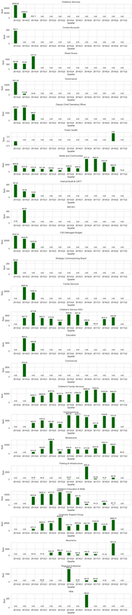

```python
quarter_agg_plotter.plot_tables(services_areas_sum_qtr, 'Sum', 'darkgreen')
```

### Transaction Average by Quarter

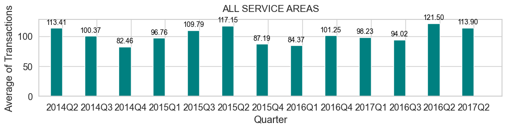

```python
### Transaction Sum by Quarter
services_areas_average_qtr_overall = quarter_agg_plotter.create_qtr_agg_table_overall(np.mean)
quarter_agg_plotter.plot_transactions_overall(services_areas_average_qtr_overall, 'Average of Transactions', 'teal')
```

```python
services_areas_average_qtr = quarter_agg_plotter.create_qtr_agg_table(np.mean)
display(services_areas_average_qtr)
```

|  | 2014Q2 | 2014Q3 | 2014Q4 | 2015Q1 | 2015Q3 | 2015Q2 | 2015Q4 | 2016Q1 | 2016Q4 | 2017Q1 | 2016Q3 | 2016Q2 | 2017Q2 |
| --- | --- | --- | --- | --- | --- | --- | --- | --- | --- | --- | --- | --- | --- |
| Childrens Services | 70.13 | 72.50 | 63.21 | 0.00 | 0.00 | 0.00 | 0.00 | 0.00 | 0.00 | 0.00 | 0.00 | 0.00 | 0.00 |
| Control Accounts | 23.84 | 0.00 | 0.00 | 0.00 | 0.00 | 0.00 | 0.00 | 0.00 | 0.00 | 0.00 | 0.00 | 0.00 | 0.00 |
| Street Scene | 57.28 | 35.66 | 110.96 | 0.00 | 0.00 | 0.00 | 0.00 | 0.00 | 0.00 | 0.00 | 0.00 | 0.00 | 0.00 |
| Governance | 3,252.90 | 392.32 | 53.94 | 0.00 | 0.00 | 0.00 | 0.00 | 0.00 | 0.00 | 0.00 | 0.00 | 0.00 | 0.00 |
| Deputy Chief Operating Officer | 39.78 | 35.27 | 35.37 | 0.00 | 0.00 | 0.00 | 0.00 | 0.00 | 0.00 | 0.00 | 0.00 | 0.00 | 0.00 |
| Public Health | -1.18 | 0.00 | 0.00 | 0.00 | 0.00 | 0.00 | 0.00 | 0.00 | 0.00 | 0.00 | 0.00 | 4.55 | 0.00 |
| Adults and Communities | 288.00 | 321.31 | 119.41 | 183.44 | 109.06 | 148.43 | 159.95 | 107.33 | 202.62 | 176.26 | 182.23 | 146.37 | 79.00 |
| Internal Audit & CAFT | 203.60 | 27.56 | 58.00 | 0.00 | 0.00 | 0.00 | 0.00 | 0.00 | 0.00 | 0.00 | 0.00 | 0.00 | 0.00 |
| NSCSO | 10.00 | 222.75 | 0.00 | 0.00 | 0.00 | 0.00 | 0.00 | 0.00 | 0.00 | 0.00 | 0.00 | 0.00 | 0.00 |
| CSG Managed Budget | 1,608.37 | 2,045.75 | 3,567.50 | 0.00 | 0.00 | 0.00 | 0.00 | 0.00 | 0.00 | 0.00 | 0.00 | 0.00 | 0.00 |
| Strategic Commissioning Board | 244.00 | 0.00 | 0.00 | 0.00 | 0.00 | 0.00 | 0.00 | 0.00 | 0.00 | 0.00 | 0.00 | 0.00 | 0.00 |
| Family Services | 0.00 | 65.83 | 57.08 | 0.00 | 0.00 | 0.00 | 0.00 | 0.00 | 0.00 | 0.00 | 0.00 | 0.00 | 0.00 |
| Children's Service DSG | 0.00 | 98.31 | 162.93 | 202.05 | 138.82 | 128.61 | 76.79 | 143.78 | 66.64 | 16.83 | 137.80 | 139.28 | 0.00 |
| Education | 0.00 | 130.97 | 141.62 | 0.00 | 0.00 | 0.00 | 0.00 | 0.00 | 0.00 | 0.00 | 0.00 | 0.00 | 0.00 |
| Commercial | 0.00 | 304.78 | 0.00 | 0.00 | 0.00 | 0.00 | 0.00 | 0.00 | 0.00 | 0.00 | 0.00 | 0.00 | 0.00 |
| Children's Family Services | 0.00 | 0.00 | 56.13 | 65.66 | 75.69 | 73.11 | 58.01 | 55.23 | 77.44 | 75.87 | 68.81 | 72.48 | 121.75 |
| Commissioning | 0.00 | 0.00 | 77.85 | 178.95 | 188.99 | 252.39 | 215.07 | 136.04 | 140.65 | 61.35 | 129.19 | 171.40 | 0.00 |
| Streetscene | 0.00 | 0.00 | 83.13 | 149.97 | 202.90 | 121.81 | 149.74 | 186.56 | 99.45 | 151.36 | 152.02 | 241.34 | 86.00 |
| Parking & Infrastructure | 0.00 | 0.00 | 46.41 | 28.43 | 0.00 | 0.00 | 159.67 | 0.00 | 1,784.12 | 58.67 | 76.25 | 500.00 | 0.00 |
| Children's Education & Skills | 0.00 | 0.00 | 111.60 | 65.67 | 112.27 | 78.28 | 129.25 | 136.03 | 208.98 | 58.05 | 148.61 | 48.17 | 0.00 |
| Customer Support Group | 0.00 | 0.00 | 298.63 | 1,350.07 | 1,353.51 | 3,148.73 | 926.27 | 1,830.31 | 1,591.13 | 2,155.40 | 1,885.29 | 2,898.88 | 0.00 |
| Assurance | 0.00 | 0.00 | 35.11 | 16.86 | 58.01 | 56.96 | 70.33 | 29.29 | 33.69 | 30.79 | -4.21 | 158.50 | 0.00 |
| Regional Enterprise | 0.00 | 0.00 | 0.00 | 60.00 | 0.00 | 0.00 | 1,645.00 | 60.00 | 226.00 | 226.00 | 12.00 | 0.00 | 0.00 |
| HRA | 0.00 | 0.00 | 0.00 | 0.00 | 0.00 | 0.00 | 0.00 | 0.00 | 289.94 | 0.00 | 0.00 | 0.00 | 0.00 |

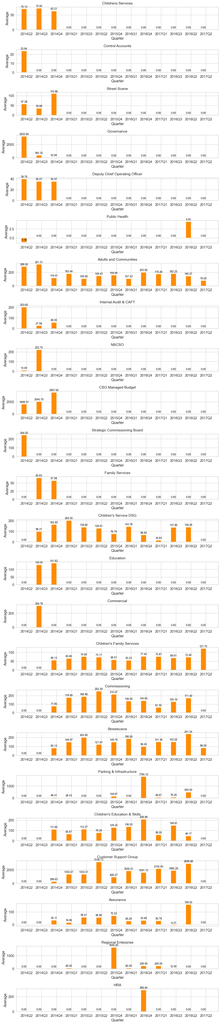

```python
quarter_agg_plotter.plot_tables(services_areas_average_qtr, 'Average', 'darkorange')
```

### Table by Quarter All Service Areas

```python
display(quarter_agg_plotter.summary_table())
```

| Service Area | Quarter | Transactions Count | Transactions Sum ($) | Transactions Average ($) |
| --- | --- | --- | --- | --- |
| Adults and Communities | 2014Q2 | 16 | 4,608 | 288 |
|  | 2014Q3 | 8 | 2,570 | 321 |
|  | 2014Q4 | 18 | 2,149 | 119 |
|  | 2015Q1 | 11 | 2,018 | 183 |
|  | 2015Q2 | 8 | 1,187 | 148 |
|  | 2015Q3 | 15 | 1,636 | 109 |
|  | 2015Q4 | 19 | 3,039 | 160 |
|  | 2016Q1 | 23 | 2,469 | 107 |
|  | 2016Q2 | 25 | 3,659 | 146 |
|  | 2016Q3 | 37 | 6,742 | 182 |
|  | 2016Q4 | 45 | 9,118 | 203 |
|  | 2017Q1 | 52 | 9,166 | 176 |
|  | 2017Q2 | 1 | 79 | 79 |
| Assurance | 2014Q4 | 3 | 105 | 35 |
|  | 2015Q1 | 4 | 67 | 17 |
|  | 2015Q2 | 52 | 2,962 | 57 |
|  | 2015Q3 | 39 | 2,262 | 58 |
|  | 2015Q4 | 30 | 2,110 | 70 |
|  | 2016Q1 | 29 | 849 | 29 |
|  | 2016Q2 | 60 | 9,510 | 159 |
|  | 2016Q3 | 36 | -151 | -4 |
|  | 2016Q4 | 53 | 1,786 | 34 |
|  | 2017Q1 | 38 | 1,170 | 31 |
| CSG Managed Budget | 2014Q2 | 20 | 32,167 | 1,608 |
|  | 2014Q3 | 12 | 24,549 | 2,046 |
|  | 2014Q4 | 4 | 14,270 | 3,568 |
| Children's Education & Skills | 2014Q4 | 72 | 8,036 | 112 |
|  | 2015Q1 | 165 | 10,836 | 66 |
|  | 2015Q2 | 160 | 12,525 | 78 |
|  | 2015Q3 | 96 | 10,778 | 112 |

[output cut: 99 more lines]

## Significant Changes in Spending Behavior

```python
accounts = np.unique(data['Account Description'])
quarters = np.unique(data['Quarter'])
num_accounts = np.unique(data['Account Description']).shape[0]
num_quarters = np.unique(data['Quarter']).shape[0]
num_services_areas = np.unique(data['Service Area']).shape[0]
services_ares = np.unique(data['Service Area'])

print('Number of Accounts:', num_accounts)
print('Number of Quarters:', num_quarters)
```

```
Number of Accounts: 67
Number of Quarters: 13
```

### Spikes

#### Service Areas

```python
# calculate account sums by quarter
account_sums_qtr = np.zeros((num_accounts, num_quarters))
for account in range(num_accounts):
    for qtr in range(num_quarters):
        account_sums_qtr[account, qtr] = np.sum(data[(data['Account Description'] == accounts[account]) & \
                                (data['Quarter'] == quarters[qtr])]['Total'])

#dataframe for account sums by quarter

account_sums_qtr_df = pd.DataFrame(account_sums_qtr, columns = quarters, index = accounts)


area_sum_qtr_means = np.array(services_areas_sum_qtr.mean(axis = 1)).reshape(-1, 1)
area_sum_qtr_vars = np.array(services_areas_sum_qtr.var(axis = 1)).reshape(-1, 1)

account_sum_qtr_means = account_sums_qtr.mean(axis = 1).reshape(-1, 1)
account_sum_qtr_vars = account_sums_qtr.var(axis = 1).reshape(-1, 1)

### calculate quarterly spikes in service areas
pd.options.display.float_format = '{:,.2f}'.format
spikes = []

for index in range(num_services_areas):
    for qtr in range(num_quarters):
        z_score = float((services_areas_sum_qtr.iloc[index, qtr] - area_sum_qtr_means[index]) \
                    / np.power(area_sum_qtr_vars[index], 0.5))
        if z_score > 2:
            spikes.append((services_ares[index], quarters[qtr], services_areas_sum_qtr.iloc[index, qtr], z_score))

spikes_df = pd.DataFrame(spikes, columns = ['Service Area', 'Quarter', 'Transaction Sum', 'SDs from Average'])
display(spikes_df.sort_values(by = 'SDs from Average', ascending = False).reset_index(drop = True))
```

[output not shown]

#### Accounts

```python
### calculate quarterly spikes in accounts

pd.options.display.float_format = '{:,.2f}'.format
spikes = []

for index in range(num_accounts):
    for qtr in range(num_quarters):
        z_score = float((account_sums_qtr[index, qtr] - account_sum_qtr_means[index]) \
                    / np.power(account_sum_qtr_vars[index], 0.5))
        if z_score > 2.0:
            spikes.append((accounts[index], quarters[qtr], account_sums_qtr[index, qtr], z_score))

spikes_df = pd.DataFrame(spikes, columns = ['Account', 'Quarter', 'Transaction Sum', 'SDs from Average'])
display(spikes_df.sort_values(by = 'SDs from Average', ascending = False).reset_index(drop = True))
```

|  | Account | Quarter | Transaction Sum | SDs from Average |
| --- | --- | --- | --- | --- |
| 0 | Counsels Fees | 2016Q1 | 1,200.00 | 3.46 |
| 1 | NNDR Collected | 2016Q2 | 4.10 | 3.46 |
| 2 | Software Purchases | 2017Q1 | 288.41 | 3.46 |
| 3 | Advertising for staff | 2016Q2 | 450.00 | 3.46 |
| 4 | Grant Payments | 2015Q3 | 660.00 | 3.46 |
| 5 | Catering Recharge | 2016Q1 | 100.00 | 3.46 |
| 6 | Clothing - Uniforms | 2014Q3 | 107.50 | 3.46 |
| 7 | Employer's National Insurance | 2015Q4 | 6.67 | 3.46 |
| 8 | Furniture-Purchase-Repair | 2015Q4 | 3,984.00 | 3.46 |
| 9 | Consultants Fees | 2016Q2 | 900.00 | 3.46 |
| 10 | Other Energy | 2014Q4 | 3,889.48 | 3.46 |
| 11 | Operating Leases - Transport | 2017Q1 | 585.00 | 3.44 |
| 12 | Equipment Hire | 2016Q2 | 1,489.20 | 3.44 |
| 13 | Ttl IT & Comms | 2016Q4 | 234.95 | 3.42 |
| 14 | Rents | 2016Q3 | 3,506.20 | 3.39 |
| 15 | Printing-Contract | 2015Q3 | 216.35 | 3.37 |
| 16 | Venue Hire | 2016Q2 | 4,342.20 | 3.32 |
| 17 | Electricity | 2017Q1 | 4,096.06 | 3.30 |
| 18 | Other Establishments - Third P | 2015Q3 | 397.86 | 3.03 |
| 19 | Gas | 2016Q2 | 1,695.22 | 3.01 |
| 20 | Education CFR Other Occupation | 2015Q4 | 45.78 | 2.93 |
| 21 | CSG - IT | 2017Q1 | 159.90 | 2.92 |
| 22 | Software Licences & Support | 2014Q2 | 189.00 | 2.86 |
| 23 | Advertising | 2015Q3 | 2,955.60 | 2.84 |
| 24 | Pool Transport Charges | 2015Q3 | 510.20 | 2.80 |
| 25 | Other Indirect Employee Expens | 2015Q4 | 737.59 | 2.78 |
| 26 | Hardware Purchases | 2017Q1 | 258.75 | 2.76 |
| 27 | Other Services | 2014Q2 | 21,559.54 | 2.76 |
| 28 | Water Services | 2017Q1 | 586.33 | 2.76 |
| 29 | E25 - Catering Supplies | 2015Q4 | 1,595.07 | 2.65 |
| 30 | Stationery | 2014Q3 | 3,238.89 | 2.62 |
| 31 | Non Education Staff GPay | 2016Q2 | 115.80 | 2.60 |
| 32 | Grounds maintenance | 2014Q4 | 682.99 | 2.57 |
| 33 | Professional Services | 2015Q1 | 3,639.18 | 2.54 |
| 34 | Publications | 2015Q4 | 1,564.23 | 2.52 |
| 35 | Parking Permit Fees | 2016Q3 | 25.26 | 2.51 |
| 36 | Miscellaneous Expenses | 2016Q4 | 14,506.72 | 2.43 |
| 37 | Training | 2016Q4 | 10,498.94 | 2.43 |
| 38 | Other Vehicle Costs | 2016Q2 | 575.83 | 2.39 |
| 39 | Subsistence | 2014Q2 | 2,577.21 | 2.34 |
| 40 | Consumable Catering Supplies | 2014Q2 | 1,663.60 | 2.33 |
| 41 | Conference Expenses | 2016Q1 | 2,633.50 | 2.29 |
| 42 | E19 - Learning Resources | 2015Q4 | 637.85 | 2.28 |
| 43 | E19 - Learning Resources | 2015Q3 | 634.15 | 2.27 |
| 44 | Education CFR Administrative S | 2015Q4 | 1,698.39 | 2.27 |
| 45 | Equipment and Materials Repair | 2015Q2 | 1,499.24 | 2.26 |
| 46 | Vehicle Running Costs | 2015Q3 | 11,527.49 | 2.22 |
| 47 | Other Vehicle Costs | 2014Q3 | 534.45 | 2.17 |
| 48 | Parking Permit Fees | 2016Q2 | 22.10 | 2.14 |
| 49 | Subsistence | 2014Q4 | 2,338.77 | 2.07 |
| 50 | Building Repairs & Maintenance | 2014Q2 | 3,061.51 | 2.06 |
| 51 | Non Education Staff GPay | 2016Q4 | 95.00 | 2.06 |
| 52 | Telephones Calls | 2014Q3 | 1,495.47 | 2.00 |

### Permanent Changes

#### Service Areas

```python
# find permanent changes in spending by service areas
changes = []
for area in range(num_services_areas):
    for qtr in range(1, num_quarters - 1):
        before_mean = services_areas_sum_qtr.iloc[area, :(qtr + 1)].mean()
        after_mean = services_areas_sum_qtr.iloc[area, (qtr + 1):].mean()
        var = services_areas_sum_qtr.iloc[area, 1:].var()
        means_diff = after_mean - before_mean
        z_score = means_diff / np.power(var, 0.5)

        # flag positive changes where long_term averages increase by more than 1 SD
        if (z_score > 1) and (services_areas_sum_qtr.iloc[area, qtr] < services_areas_sum_qtr.iloc[area, (qtr + 1)]):
            changes.append((services_ares[area], quarters[qtr + 1], before_mean, after_mean, z_score))

changes_df = pd.DataFrame(changes, columns = ['Service Area', 'After Quarter', 'Old Average', \
                                             'New Average', 'SDs Change'])
changes_df = changes_df[changes_df['Old Average'] > 0]
display(changes_df.reset_index(drop = True))
```

[output not shown]

#### Accounts

```python
# find permanent changes in spending by accounts
changes = []
for account in range(num_accounts):
    for qtr in range(1, num_quarters - 1):
        before_mean = account_sums_qtr[account, :(qtr + 1)].mean()
        after_mean = account_sums_qtr[account, (qtr + 1):].mean()
        var = account_sums_qtr[account, 1:].var()
        means_diff = after_mean - before_mean
        z_score = means_diff / np.power(var, 0.5)

        # flag positive changes where long_term averages increase by more than 1 SD
        if (z_score > 1) and (services_areas_sum_qtr.iloc[area, qtr] < services_areas_sum_qtr.iloc[area, (qtr + 1)]):
            changes.append((accounts[account], quarters[qtr + 1], before_mean, after_mean, z_score))

changes_df = pd.DataFrame(changes, columns = ['Account', 'Starting Quarter', 'Old Average', \
                                             'New Average', 'SDs Change'])
changes_df = changes_df[changes_df['New Average'] > 0]
display(changes_df.reset_index(drop = True))
```

|  | Account | Starting Quarter | Old Average | New Average | SDs Change |
| --- | --- | --- | --- | --- | --- |
| 0 | CSG - IT | 2016Q2 | 0.00 | 51.48 | 1.04 |
| 1 | Gas | 2016Q2 | 0.00 | 589.42 | 1.17 |
| 2 | Laundry and Dry Cleaning | 2016Q2 | 0.00 | 23.69 | 1.55 |
| 3 | Miscellaneous Expenses | 2016Q2 | 3,559.18 | 7,560.38 | 1.02 |
| 4 | Non Education Staff GPay | 2016Q2 | 0.00 | 42.16 | 1.07 |
| 5 | Other Transfer Payments to Soc | 2016Q2 | 4,067.88 | 8,614.05 | 1.20 |
| 6 | Parking Permit Fees | 2016Q2 | 0.00 | 10.07 | 1.15 |
| 7 | Telephone Rentals | 2016Q2 | 58.26 | 270.65 | 1.23 |

## Classifying Creditors to Accounts

```python
data.head(3)
```

|  | Service Area | Account Description | Creditor | Journal Date | JV Reference | Total | Quarter |
| --- | --- | --- | --- | --- | --- | --- | --- |
| 0 | Childrens Services | IT Services | 123-REG.CO.UK | 2014-04-23 | 93.00 | 143.81 | 2014Q2 |
| 1 | Childrens Services | Other Services | ACCESS EXPEDITIONS | 2014-04-03 | 111.00 | 6,000.00 | 2014Q2 |
| 2 | Childrens Services | Equipment and Materials Repair | AFE SERVICELINE | 2014-04-02 | 6.00 | 309.38 | 2014Q2 |

```python
### find multi-classified creditors

pd.set_option('display.max_colwidth', 1000)

# count accounts per creditor
num_creditor_accounts = []
for creditor in range(num_creditors):
    accounts = np.unique(data[data['Creditor'] == creditors[creditor]]['Account Description'])
    accounts_str = ', '.join(accounts)
    num_creditor_accounts.append((creditors[creditor], len(accounts), accounts_str))

# find multi-classified creditors
accounts_df = pd.DataFrame(num_creditor_accounts, columns = ['Creditor', '# Accounts',
                                                                   'Account'])
multi_accounts_df = accounts_df[accounts_df['# Accounts'] > 1]
multi_accounts_df = multi_accounts_df.sort_values(by = '# Accounts', ascending = False)
```

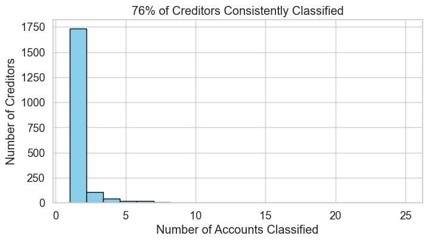

```python
# Calculate the percentage of correctly classified creditors
pct_correctly_classed = 100 - int(round(multi_accounts_df.shape[0] / float(accounts_df.shape[0]) * 100))

# Create a histogram plot for the '# Accounts' column in accounts_df
fig, ax = plt.subplots(figsize=(8, 4))
ax.hist(accounts_df['# Accounts'], bins=20, color='skyblue', edgecolor='black')

# Set labels and title for better clarity
ax.set_xlabel("Number of Accounts Classified")
ax.set_ylabel("Number of Creditors")
ax.set_title(f"{pct_correctly_classed}% of Creditors Consistently Classified")

# Display the plot
plt.show()
```

```python
display(multi_accounts_df.reset_index(drop = True))
```

|  | Creditor | # Accounts | Account |
| --- | --- | --- | --- |
| 0 | AMAZON UK MARKETPLACE | 25 | Advertising, Books-CDs-Audio-Video, Building Repairs & Maintenance, CSG - IT, Cleaning and domestic material, Consumable Catering Supplies, E19 - Learning Resources, E25 - Catering Supplies, Education… |
| 1 | AMAZON EU | 18 | Books-CDs-Audio-Video, Building Repairs & Maintenance, Cleaning and domestic material, E19 - Learning Resources, Education CFR Administrative S, Education CFR Other Occupation, Equipment and Materials… |
| 2 | AMAZON UK RETAIL AMAZO | 15 | Books-CDs-Audio-Video, Building Repairs & Maintenance, CSG - IT, Cleaning and domestic material, Equipment and Materials Purcha, Food Costs, General Office Expenses, Hardware Purchases, Miscellaneous … |
| 3 | AMAZON SVCS EUROPE,SAR | 14 | Books-CDs-Audio-Video, Building Repairs & Maintenance, Consumable Catering Supplies, E25 - Catering Supplies, Education CFR Administrative S, Equipment and Materials Purcha, General Office Expenses, H… |
| 4 | ASDA SUPERSTORE | 13 | Books-CDs-Audio-Video, Building Repairs & Maintenance, Cleaning and domestic material, E19 - Learning Resources, E25 - Catering Supplies, Equipment and Materials Purcha, Food Costs, Other Services, Ot… |
| ... | ... | ... | ... |
| 469 | Lynette Headley-JoneCO-OP GROUP | 2 | Food Costs, Other Transfer Payments to Soc |
| 470 | LUL TICKET OFFICE. | 2 | Other Transfer Payments to Soc, Travelling Expenses |
| 471 | LONDON BOROUGH OF HARR | 2 | Operating Leases - Transport, Vehicle Running Costs |
| 472 | LB BRENT PARKING PCNS | 2 | Operating Leases - Transport, Vehicle Running Costs |
| 473 | ZAHRA NEWSAGENT | 2 | Books-CDs-Audio-Video, Food Costs |

474 rows × 3 columns

## Grouping Service Areas

K-means clustering is a popular method for grouping data points into clusters based on their similarity. The algorithm is particularly useful for identifying patterns and trends in data, which is essential for our analysis. We will use the K-means algorithm to group service areas based on their spending behavior. The algorithm will identify clusters of service areas that exhibit similar spending patterns, allowing us to identify groups of service areas that behave similarly.

```python
from sklearn.cluster import KMeans

area_counts = np.array(services_areas_counts_qtr.sum(axis = 1)).reshape(-1, 1).astype(int)
area_means = np.array(services_areas_sum_qtr.sum(axis = 1)).reshape(-1, 1).astype(float) / area_counts

## prepare predictors
predictors = np.concatenate((area_counts, area_means), axis = 1)

# create and fit K-means model
n_clusters = 4

model = KMeans(n_clusters = n_clusters)
predict = model.fit_predict(predictors)
cluster_centers = model.cluster_centers_

new_col = np.zeros(data.shape[0]).reshape(-1, 1)
for index in range(num_services_areas):
    area_name = services_ares[index]
    area_indexes = np.where(data['Service Area'] == area_name)
    new_col[area_indexes] = predict[index]

new_col_df = pd.DataFrame(new_col, columns = ['Cluster'])
data_kmeans = pd.concat((data, new_col_df), axis = 1)
```

```python
# group clusters with service area names
results = np.concatenate((predict.reshape(-1, 1), services_ares.reshape(-1, 1)), axis = 1)
results_df = pd.DataFrame(results, columns = ['Cluster', 'Service Area'])
clusters = results_df.groupby('Cluster')
```

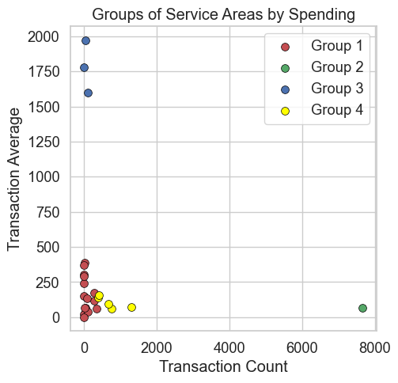

```python
### plot clusters
colors = ['r', 'g', 'b', 'yellow']

fig = plt.figure(figsize = (5, 5))
ax = fig.add_subplot(1, 1, 1)

for cluster in range(n_clusters):
    cluster_counts = area_counts[predict == cluster]
    cluster_means = area_means[predict == cluster]
    ax.scatter(cluster_counts, cluster_means, color = colors[cluster], s = 50,
               edgecolor = 'black', linewidth = 0.5, label = 'Group ' + str(cluster + 1))

ax.set_xlabel("Transaction Count")
ax.set_ylabel("Transaction Average")
ax.set_title("Groups of Service Areas by Spending")
ax.legend(loc = 'best')

plt.show()
```

## Anomaly Detection

```python
# find service areas with < 5 transactions in this time period
min_transactions = 5

many_xact_areas = []
few_xact_areas = []

for index in range(num_services_areas):
    area_name = services_ares[index]
    num_xacts = np.count_nonzero(data[data['Service Area'] == area_name]['Total'])
    if num_xacts >= min_transactions:
        many_xact_areas.append((area_name, num_xacts))
    else:
        few_xact_areas.append((area_name, num_xacts))

many_xact_areas_df = pd.DataFrame(many_xact_areas, columns = \
                                  ['Service Area', 'Number of Transactions'])

few_xact_areas_df = pd.DataFrame(few_xact_areas, columns = \
                                 ['Service Area', 'Number of Transactions'])
display(few_xact_areas_df.reset_index(drop = True))
```

|  | Service Area | Number of Transactions |
| --- | --- | --- |
| 0 | HRA | 1 |
| 1 | NSCSO | 3 |
| 2 | Public Health | 3 |
| 3 | Strategic Commissioning Board | 1 |

### Frequencies of transaction amounts

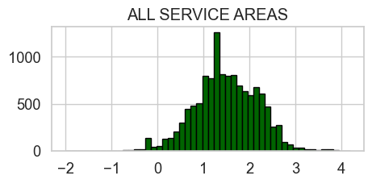

```python
fig, ax = plt.subplots(1, 1, figsize = (5, 2))
ax.hist(np.log10(data[data['Total'] > 0]['Total']), bins = 50, color = 'darkgreen', edgecolor = 'black')
ax.set_title("All Service Areas".upper())
plt.show()
```

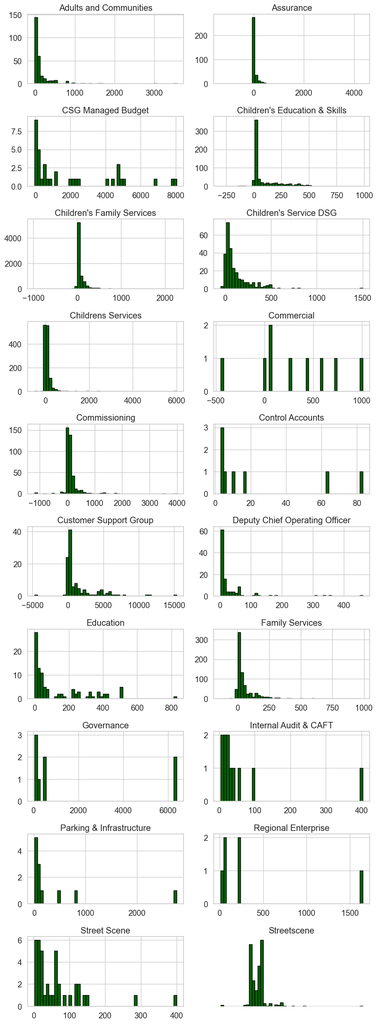

```python
num_areas = many_xact_areas_df.shape[0]
fig, ax_ar = plt.subplots((num_areas // 2) + (num_areas % 2), 2, figsize = (9, 24))

for index in range(num_areas):
    area = many_xact_areas_df.iloc[index, 0]
    area_data = data[data['Service Area'] == area]['Total']

    ax_ar[index // 2, index % 2].hist(area_data, bins = 50, color = 'darkgreen', edgecolor = 'black')
    ax_ar[index // 2, index % 2].set_title(area)

ax_ar[-1, -1].axis('off')
plt.tight_layout()
plt.show()
```

```python
### calculate percentiles of transaction amounts for each many-transaction service area

avg_col = np.zeros(num_areas).reshape(-1, 1)
var_col = np.zeros(num_areas).reshape(-1, 1)
percentile_col = np.zeros(data.shape[0])

for index in range(num_areas):
    area_name = many_xact_areas_df.iloc[index, 0]
    area_indexes = np.where(data['Service Area'] == area_name)
    area_totals = data.iloc[area_indexes]['Total'].values

    avg_col[index] = area_totals.mean()
    var_col[index] = area_totals.var()

    dist = norm(avg_col[index], np.power(var_col[index], 0.5))
    percentile_col[area_indexes] = dist.cdf(data.iloc[area_indexes]['Total'].values)

avg_col_df = pd.DataFrame(avg_col, columns = ['Average'])
var_col_df = pd.DataFrame(var_col, columns = ['Variance'])
stat_cols_df = pd.concat((avg_col_df, var_col_df), axis = 1)
many_xact_areas_df = pd.concat((many_xact_areas_df, stat_cols_df), axis = 1)

percentile_col_df = pd.DataFrame(percentile_col.reshape(-1, 1), columns = ['Percentile'])
data = pd.concat((data, percentile_col_df), axis = 1)
```

```python
pd.options.display.float_format = '{:,.2f}'.format

anomaly_threshold = 0.98
anomalous_data = data[data['Percentile'] > anomaly_threshold]


for index in range(num_areas):
    area_name = many_xact_areas_df.iloc[index, 0]

    area_data = anomalous_data[anomalous_data['Service Area'] == area_name]
    if (area_data.shape[0] >= min_transactions):
        area_data = area_data.sort_values(by = 'Percentile', ascending = False)
        caveat_str = ""
    else:
        extra_transactions = min_transactions - area_data.shape[0]
        caveat_str = "  (" + str(extra_transactions) + \
                        " extra transactions listed to meet analysis requests)"

        area_data = data[data['Service Area'] == area_name].sort_values(by = ['Percentile', 'Journal Date'],
                                                                        ascending = False)
        area_data = area_data.iloc[:min_transactions, :]

    display(area_data.head(min_transactions))



#Table with anomalous data just 5 transactions per service area
```

|  | Service Area | Account Description | Creditor | Journal Date | JV Reference | Total | Quarter | Percentile |
| --- | --- | --- | --- | --- | --- | --- | --- | --- |
| 8013 | Adults and Communities | CSG - IT | AMAZON UK RETAIL AMAZO | 2017-02-01 | 10,975.00 | 62.40 | 2017Q1 | 1.00 |
| 8064 | Adults and Communities | Postage | WWW.ROYALMAIL.COM | 2016-06-29 | 8,573.00 | 128.00 | 2016Q2 | 1.00 |
| 8046 | Adults and Communities | Other Agencies - Third Party P | HOLIDAY INNS | 2016-12-09 | 10,578.00 | 830.00 | 2016Q4 | 1.00 |
| 8047 | Adults and Communities | Other Agencies - Third Party P | HOLIDAY INNS | 2016-11-22 | 10,349.00 | 1,670.30 | 2016Q4 | 1.00 |
| 5689 | Adults and Communities | Publications | GUARDIAN NEWS & MEDIA | 2015-12-04 | 6,273.00 | 1,391.04 | 2015Q4 | 1.00 |

|  | Service Area | Account Description | Creditor | Journal Date | JV Reference | Total | Quarter | Percentile |
| --- | --- | --- | --- | --- | --- | --- | --- | --- |
| 8368 | Assurance | Vehicle Running Costs | TFL ROAD CHARGE | 2017-01-30 | 10,837.00 | 11.50 | 2017Q1 | 1.00 |
| 8205 | Assurance | Equipment and Materials Repair | M CAMELIA IACOB LT | 2016-04-19 | 7,810.00 | 48.48 | 2016Q2 | 1.00 |
| 7594 | Assurance | General Office Expenses | WWW.CLOTHES2ORDER.C | 2015-05-21 | 5,729.00 | 1,276.92 | 2015Q2 | 1.00 |
| 8227 | Assurance | Miscellaneous Expenses | BIRMINGHAM CC | 2016-04-25 | 7,891.00 | 13.00 | 2016Q2 | 1.00 |
| 8369 | Assurance | Venue Hire | ALEXANDRA PALACE | 2016-05-02 | 7,960.00 | 4,342.20 | 2016Q2 | 1.00 |

|  | Service Area | Account Description | Creditor | Journal Date | JV Reference | Total | Quarter | Percentile |
| --- | --- | --- | --- | --- | --- | --- | --- | --- |
| 1856 | CSG Managed Budget | Legal and Court Fees | HMCOURTS-SERVICE.G | 2014-09-23 | 2,235.00 | 8,058.00 | 2014Q3 | 0.99 |
| 531 | CSG Managed Budget | Legal and Court Fees | HMCOURTS-SERVICE.G | 2014-05-22 | 498.00 | 7,800.00 | 2014Q2 | 0.99 |
| 532 | CSG Managed Budget | Legal and Court Fees | HMCOURTS-SERVICE.G | 2014-05-22 | 497.00 | 6,777.00 | 2014Q2 | 0.98 |
| 1544 | CSG Managed Budget | Legal and Court Fees | HMCOURTS-SERVICE.G | 2014-08-19 | 1,914.00 | 4,998.00 | 2014Q3 | 0.90 |
| 889 | CSG Managed Budget | Legal and Court Fees | HMCOURTS-SERVICE.G | 2014-06-17 | 1,245.00 | 4,977.00 | 2014Q2 | 0.89 |

|  | Service Area | Account Description | Creditor | Journal Date | JV Reference | Total | Quarter | Percentile |
| --- | --- | --- | --- | --- | --- | --- | --- | --- |
| 6393 | Children's Education & Skills | Training | PENTAGON | 2015-06-18 | 4,344.00 | 987.47 | 2015Q2 | 1.00 |
| 8371 | Children's Education & Skills | Conference Expenses | THE NOKE HOTEL | 2016-09-08 | 9,372.00 | 725.00 | 2016Q3 | 1.00 |
| 8404 | Children's Education & Skills | Travelling Expenses | TRAINLINE.COM LTD | 2016-10-04 | 9,705.00 | 79.35 | 2016Q4 | 1.00 |
| 3982 | Children's Education & Skills | Books-CDs-Audio-Video | SP DOWN SYNDROME E | 2015-02-10 | 5,101.00 | 730.44 | 2015Q1 | 1.00 |
| 8370 | Children's Education & Skills | Conference Expenses | EB SPECIAL EDUCATIONA | 2016-11-09 | 10,180.00 | 500.00 | 2016Q4 | 1.00 |

|  | Service Area | Account Description | Creditor | Journal Date | JV Reference | Total | Quarter | Percentile |
| --- | --- | --- | --- | --- | --- | --- | --- | --- |
| 10304 | Children's Family Services | Miscellaneous Expenses | CAPITALHAIRANDBEAU01273 331122 | 2016-09-12 | 9,448.00 | -97.13 | 2016Q3 | 1.00 |
| 10190 | Children's Family Services | Gas | BRITISH GAS BUSINE | 2017-01-20 | 11,161.00 | 854.00 | 2017Q1 | 1.00 |
| 4834 | Children's Family Services | Other Transfer Payments to Soc | ARGOS B2B ONLINE | 2015-05-28 | 3,249.00 | 1,240.86 | 2015Q2 | 1.00 |
| 6995 | Children's Family Services | Other Agencies - Third Party P | SOUTH MIMMS TRAVEL | 2015-07-23 | 4,771.00 | 2,262.91 | 2015Q3 | 1.00 |
| 7875 | Children's Family Services | Other Agencies - Third Party P | WWW.ILXGROUP.COM | 2015-12-02 | 6,242.00 | 1,954.80 | 2015Q4 | 1.00 |

|  | Service Area | Account Description | Creditor | Journal Date | JV Reference | Total | Quarter | Percentile |
| --- | --- | --- | --- | --- | --- | --- | --- | --- |
| 12109 | Children's Service DSG | Subscriptions | MAGSUBCRIPTIONS COM | 2016-06-21 | 8,471.00 | 116.00 | 2016Q2 | 1.00 |
| 12078 | Children's Service DSG | Equipment and Materials Purcha | WWW.CONNEVANS.COM | 2016-04-08 | 7,716.00 | 45.60 | 2016Q2 | 1.00 |
| 5794 | Children's Service DSG | Equipment and Materials Purcha | HP INC UK LIMITED | 2015-12-18 | 6,444.00 | 749.17 | 2015Q4 | 1.00 |
| 6352 | Children's Service DSG | Training | PAYATRADER | 2015-05-28 | 3,250.00 | 584.00 | 2015Q2 | 1.00 |
| 3480 | Children's Service DSG | Training | PAYATRADER | 2015-01-08 | 4,810.00 | 520.00 | 2015Q1 | 0.99 |

|  | Service Area | Account Description | Creditor | Journal Date | JV Reference | Total | Quarter | Percentile |
| --- | --- | --- | --- | --- | --- | --- | --- | --- |
| 1 | Childrens Services | Other Services | ACCESS EXPEDITIONS | 2014-04-03 | 111.00 | 6,000.00 | 2014Q2 | 1.00 |
| 500 | Childrens Services | Travelling Expenses | CURRIE MOTORS CAR | 2014-05-23 | 391.00 | 1,960.00 | 2014Q2 | 1.00 |
| 1202 | Childrens Services | Miscellaneous Expenses | HERTSMERE BOROUGH | 2014-07-03 | 1,256.00 | 2,439.16 | 2014Q3 | 1.00 |
| 863 | Childrens Services | Legal and Court Fees | COUNCIL TAX | 2014-06-16 | 942.00 | 1,406.50 | 2014Q2 | 1.00 |
| 1262 | Childrens Services | Other Services | MOTORSPORT WORLD LT | 2014-08-01 | 1,415.00 | 983.40 | 2014Q3 | 1.00 |

|  | Service Area | Account Description | Creditor | Journal Date | JV Reference | Total | Quarter | Percentile |
| --- | --- | --- | --- | --- | --- | --- | --- | --- |
| 1748 | Commercial | Private Contractors - Third Pa | WWW.TELECARE.ORG.UK | 2014-08-25 | 1,898.00 | 1,008.00 | 2014Q3 | 0.96 |
| 1738 | Commercial | Private Contractors - Third Pa | WWW.FRIDGELAND.CO.U | 2014-08-22 | 1,897.00 | 717.35 | 2014Q3 | 0.84 |
| 1673 | Commercial | Subscriptions | SOLACE LTD | 2014-08-18 | 1,895.00 | 594.00 | 2014Q3 | 0.76 |
| 1842 | Commercial | Private Contractors - Third Pa | EB LOCAL AUTHORITIE | 2014-09-08 | 2,222.00 | 450.00 | 2014Q3 | 0.64 |
| 1489 | Commercial | Equipment and Materials Purcha | BRITISH GAS TRADIN | 2014-08-18 | 1,896.00 | 262.75 | 2014Q3 | 0.46 |

|  | Service Area | Account Description | Creditor | Journal Date | JV Reference | Total | Quarter | Percentile |
| --- | --- | --- | --- | --- | --- | --- | --- | --- |
| 7920 | Commissioning | Furniture-Purchase-Repair | WWW.OFFICEFURNITUREONL | 2015-10-02 | 5,525.00 | 3,984.00 | 2015Q4 | 1.00 |
| 12321 | Commissioning | Travelling Expenses | TRAINLINE | 2016-09-02 | 9,321.00 | 240.82 | 2016Q3 | 1.00 |
| 12316 | Commissioning | Training | THE COACHING ACADEMY | 2016-06-29 | 8,565.00 | 450.00 | 2016Q2 | 1.00 |
| 12274 | Commissioning | Miscellaneous Expenses | HFE SIGNS LTD | 2016-12-05 | 10,514.00 | 79.18 | 2016Q4 | 1.00 |
| 6094 | Commissioning | Building Repairs & Maintenance | MET PARKING SERVICES L | 2015-06-02 | 3,298.00 | 1,740.00 | 2015Q2 | 1.00 |

|  | Service Area | Account Description | Creditor | Journal Date | JV Reference | Total | Quarter | Percentile |
| --- | --- | --- | --- | --- | --- | --- | --- | --- |
| 38 | Control Accounts | Other Transfer Payments to Soc | Amazon *Mktplce EU- | 2014-04-07 | 101.00 | 83.31 | 2014Q2 | 0.98 |
| 784 | Control Accounts | Miscellaneous Expenses | ARGOS RETAIL GROUP | 2014-06-13 | 1,019.00 | 63.94 | 2014Q2 | 0.91 |
| 43 | Control Accounts | Other Transfer Payments to Soc | Amazon *Mktplce EU- | 2014-04-03 | 97.00 | 15.99 | 2014Q2 | 0.39 |
| 40 | Control Accounts | Other Transfer Payments to Soc | Amazon *Mktplce EU- | 2014-04-03 | 96.00 | 10.99 | 2014Q2 | 0.33 |
| 41 | Control Accounts | Other Transfer Payments to Soc | Amazon *Mktplce EU- | 2014-04-04 | 98.00 | 5.28 | 2014Q2 | 0.26 |

|  | Service Area | Account Description | Creditor | Journal Date | JV Reference | Total | Quarter | Percentile |
| --- | --- | --- | --- | --- | --- | --- | --- | --- |
| 5730 | Customer Support Group | Fees and Charges | HMCOURTS-SERVICE.G | 2015-05-20 | 3,161.00 | 15,340.80 | 2015Q2 | 1.00 |
| 12349 | Customer Support Group | Legal and Court Fees | HMCOURTS-SERVICE.G | 2017-03-23 | 11,896.00 | 4,443.00 | 2017Q1 | 1.00 |
| 12352 | Customer Support Group | Legal and Court Fees | HMCOURTS-SERVICE.G | 2017-01-24 | 10,993.00 | 1,225.00 | 2017Q1 | 1.00 |
| 12358 | Customer Support Group | Legal and Court Fees | HMCOURTS-SERVICE.G | 2017-01-30 | 10,994.00 | 174.00 | 2017Q1 | 0.99 |
| 5731 | Customer Support Group | Fees and Charges | HMCOURTS-SERVICE.G | 2015-07-21 | 4,722.00 | 6,955.20 | 2015Q3 | 0.98 |

|  | Service Area | Account Description | Creditor | Journal Date | JV Reference | Total | Quarter | Percentile |
| --- | --- | --- | --- | --- | --- | --- | --- | --- |
| 2207 | Deputy Chief Operating Officer | Travelling Expenses | EUROSTAR INTERNATIO | 2014-10-10 | 3,289.00 | 460.00 | 2014Q4 | 1.00 |
| 334 | Deputy Chief Operating Officer | Training | WWW.WESTMINSTER-BRI | 2014-04-02 | 189.00 | 354.00 | 2014Q2 | 1.00 |
| 962 | Deputy Chief Operating Officer | Grounds maintenance | PINKS SPIRES | 2014-06-03 | 1,026.00 | 340.00 | 2014Q2 | 1.00 |
| 1214 | Deputy Chief Operating Officer | Equipment and Materials Purcha | INSPIRED FRAMES | 2014-07-11 | 1,347.00 | 312.50 | 2014Q3 | 1.00 |
| 1215 | Deputy Chief Operating Officer | Equipment and Materials Purcha | INSPIRED FRAMES | 2014-07-11 | 1,348.00 | 182.50 | 2014Q3 | 0.98 |

|  | Service Area | Account Description | Creditor | Journal Date | JV Reference | Total | Quarter | Percentile |
| --- | --- | --- | --- | --- | --- | --- | --- | --- |
| 1920 | Education | Books-CDs-Audio-Video | PEARSON ED LTD | 2014-09-25 | 2,244.00 | 830.10 | 2014Q3 | 1.00 |
| 1497 | Education | Equipment and Materials Purcha | CE-CES LTD | 2014-08-12 | 1,629.00 | 500.00 | 2014Q3 | 0.98 |
| 1832 | Education | Private Contractors - Third Pa | CE-CES LTD | 2014-09-23 | 2,098.00 | 500.00 | 2014Q3 | 0.98 |
| 1833 | Education | Equipment and Materials Purcha | CE-CES LTD | 2014-09-03 | 1,957.00 | 500.00 | 2014Q3 | 0.98 |
| 2185 | Education | Equipment and Materials Purcha | CE-CES LTD | 2014-10-21 | 3,124.00 | 500.00 | 2014Q4 | 0.98 |

|  | Service Area | Account Description | Creditor | Journal Date | JV Reference | Total | Quarter | Percentile |
| --- | --- | --- | --- | --- | --- | --- | --- | --- |
| 1525 | Family Services | Miscellaneous Expenses | EQUITA LTD | 2014-08-27 | 1,714.00 | 989.29 | 2014Q3 | 1.00 |
| 1969 | Family Services | Equipment and Materials Purcha | TESCO DIRECT | 2014-09-19 | 2,213.00 | 914.00 | 2014Q3 | 1.00 |
| 2061 | Family Services | Other Transfer Payments to Soc | ARGOS DIRECT | 2014-10-16 | 3,489.00 | 890.95 | 2014Q4 | 1.00 |
| 2426 | Family Services | Private Contractors - Third Pa | TICKETMASTER UK | 2014-10-27 | 3,365.00 | 850.00 | 2014Q4 | 1.00 |
| 1595 | Family Services | Other Services | MAPYXLIMITE | 2014-08-22 | 1,794.00 | 695.40 | 2014Q3 | 1.00 |

|  | Service Area | Account Description | Creditor | Journal Date | JV Reference | Total | Quarter | Percentile |
| --- | --- | --- | --- | --- | --- | --- | --- | --- |
| 77 | Governance | Other Services | BETTER LIFE HEALTH | 2014-04-24 | 286.00 | 6,388.20 | 2014Q2 | 0.96 |
| 78 | Governance | Other Services | BETTER LIFE HEALTH | 2014-04-24 | 287.00 | 6,388.20 | 2014Q2 | 0.96 |
| 2029 | Governance | Stationery | WWW.CARTRIDGESAVE.C | 2014-09-12 | 2,153.00 | 480.03 | 2014Q3 | 0.31 |
| 2030 | Governance | Stationery | WWW.CARTRIDGESAVE.C | 2014-09-24 | 2,155.00 | 444.93 | 2014Q3 | 0.31 |
| 1056 | Governance | Professional Services | WESTMINSTER FORUM | 2014-07-01 | 1,198.00 | 252.00 | 2014Q3 | 0.28 |

|  | Service Area | Account Description | Creditor | Journal Date | JV Reference | Total | Quarter | Percentile |
| --- | --- | --- | --- | --- | --- | --- | --- | --- |
| 860 | Internal Audit & CAFT | Equipment and Materials Purcha | CANFORD AUDIO PLC | 2014-06-19 | 1,195.00 | 403.20 | 2014Q2 | 1.00 |
| 2205 | Internal Audit & CAFT | Private Contractors - Third Pa | EB TENANCY FRAUD FO | 2014-10-30 | 3,504.00 | 99.00 | 2014Q4 | 0.62 |
| 1519 | Internal Audit & CAFT | Equipment and Materials Purcha | D H C LTD | 2014-08-04 | 1,931.00 | 56.07 | 2014Q3 | 0.47 |
| 1178 | Internal Audit & CAFT | Equipment and Materials Purcha | D H C LTD | 2014-07-25 | 1,617.00 | 37.08 | 2014Q3 | 0.40 |
| 1162 | Internal Audit & CAFT | Legal and Court Fees | BARNET REGISTER OFF | 2014-07-14 | 1,417.00 | 30.00 | 2014Q3 | 0.37 |

|  | Service Area | Account Description | Creditor | Journal Date | JV Reference | Total | Quarter | Percentile |
| --- | --- | --- | --- | --- | --- | --- | --- | --- |
| 12374 | Parking & Infrastructure | Miscellaneous Expenses | NOCHEX. BPH POSTCODES | 2016-06-15 | 8,392.00 | 500.00 | 2016Q2 | 1.00 |
| 12372 | Parking & Infrastructure | Equipment and Materials Purcha | AMAZON UK MARKETPLACE | 2016-07-29 | 8,963.00 | 76.25 | 2016Q3 | 0.71 |
| 12373 | Parking & Infrastructure | Equipment and Materials Purcha | WWW.MIDLANDPALLETTRUCK | 2016-12-16 | 10,668.00 | 795.00 | 2016Q4 | 0.56 |
| 4304 | Parking & Infrastructure | Equipment and Materials Purcha | AMAZON EU | 2015-10-01 | 5,497.00 | 159.67 | 2015Q4 | 0.38 |
| 12370 | Parking & Infrastructure | Equipment and Materials Purcha | AMAZON UK MARKETPLACE | 2017-02-15 | 11,453.00 | 67.94 | 2017Q1 | 0.36 |

|  | Service Area | Account Description | Creditor | Journal Date | JV Reference | Total | Quarter | Percentile |
| --- | --- | --- | --- | --- | --- | --- | --- | --- |
| 12380 | Regional Enterprise | Subscriptions | COMPANIES HOUSE | 2016-08-11 | 9,079.00 | 12.00 | 2016Q3 | 1.00 |
| 5872 | Regional Enterprise | Professional Services | J W RUDDOCK &SONS LTD | 2015-12-01 | 6,227.00 | 1,645.00 | 2015Q4 | 0.99 |
| 12378 | Regional Enterprise | Other Services | HMCOURTS-SERVICE.G | 2017-01-12 | 11,246.00 | 226.00 | 2017Q1 | 0.40 |
| 12377 | Regional Enterprise | Consultants Fees | WWW.COMPANYWATCH.NET | 2016-03-14 | 7,443.00 | 60.00 | 2016Q1 | 0.40 |
| 3613 | Regional Enterprise | Equipment and Materials Purcha | WWW.COMPANYWATCH.NE | 2015-01-22 | 4,502.00 | 60.00 | 2015Q1 | 0.29 |

|  | Service Area | Account Description | Creditor | Journal Date | JV Reference | Total | Quarter | Percentile |
| --- | --- | --- | --- | --- | --- | --- | --- | --- |
| 2328 | Street Scene | Vehicle Running Costs | POST OFFICE COUNTER | 2014-10-29 | 3,507.00 | 400.00 | 2014Q4 | 1.00 |
| 2329 | Street Scene | Vehicle Running Costs | POST OFFICE COUNTER | 2014-10-29 | 3,506.00 | 287.50 | 2014Q4 | 1.00 |
| 2432 | Street Scene | Training | VOSA-TRAINING | 2014-10-23 | 3,505.00 | 151.80 | 2014Q4 | 0.87 |
| 2466 | Street Scene | Equipment and Materials Purcha | WWW.STANTONHOPE.CO. | 2014-10-13 | 3,109.00 | 145.14 | 2014Q4 | 0.85 |
| 2120 | Street Scene | Equipment and Materials Purcha | Amazon EU | 2014-10-03 | 3,107.00 | 123.29 | 2014Q4 | 0.77 |

|  | Service Area | Account Description | Creditor | Journal Date | JV Reference | Total | Quarter | Percentile |
| --- | --- | --- | --- | --- | --- | --- | --- | --- |
| 5710 | Streetscene | Advertising | HAYMARKET PUBLISHI | 2015-08-12 | 4,980.00 | 2,295.60 | 2015Q3 | 1.00 |
| 5510 | Streetscene | Equipment and Materials Purcha | DIRECT 365ONLINE LTD | 2015-10-01 | 5,508.00 | 1,098.00 | 2015Q4 | 1.00 |
| 3836 | Streetscene | Other Services | BRITISH STANDARDS | 2015-02-16 | 5,200.00 | 717.95 | 2015Q1 | 1.00 |
| 7651 | Streetscene | Vehicle Running Costs | WWW.DVLA.GOV.UK | 2015-07-13 | 4,629.00 | 652.50 | 2015Q3 | 1.00 |
| 7674 | Streetscene | Vehicle Running Costs | WWW.DVLA.GOV.UK | 2015-06-22 | 4,368.00 | 652.50 | 2015Q2 | 1.00 |